# Machine Learning - GLM

Carlos Grande Nuñez, Veronica Gomez Gomez y Pablo Olmos Martinez

13/02/2020

# GLM

La principal aportación de la regresión logística consiste en extener el modelo teórico de la regresión simple y multivariante, para aplicarla a problemas en los que la variable de salida del modelo es discreta o categórica, en lugar de continua.

### Objetivo de Negocio y Definición del Target

Nuestro objetivo de negocio es generar estructural departamentales y para ello necesitamos definir dos grandes grupos principalmente. Por un Lado buscamos los perfiles de casas de Alto Poder adquisitivo versus el Resto. Para ello nos apoyaremos de la Regresión Logística y necesitaremos definir un cluster 1/0 en el que las casas con valor 1 son aquellas de alto poder adquisitivo o Precio alto y 0 el resto de casas. ¿cómo definimos este punto de corte? Vamos a leer nuestra BBDD y estudiar la variable precio para encontrar el punto de corte óptimo para nuestro análisis

### Lectura de Nuestra Base cluster.

```r
#setwd("C:/Users/Pablo/Desktop/Machine_Learning_I/Z_PRACTICA_MACHINE_LEARNING/machineLearning1Process")
df_cluster <- read.csv ("../cluster.csv")
#setwd("C:/Users/Pablo/Desktop/Machine_Learning_I/Z_PRACTICA_MACHINE_LEARNING/machineLearning1Process")
df_root <- read.csv ("../kc_house_data.csv")


df_cluster$hclust=as.numeric(df_cluster$hclust)
df_cluster$cluster_final[df_cluster$hclust==2 | df_cluster$hclust==8] <- "top"
df_cluster$cluster_final[df_cluster$hclust==1 | df_cluster$hclust==5 | df_cluster$hclust==9] <- "low"
df_cluster$cluster_final[df_cluster$hclust==3 | df_cluster$hclust==4 | df_cluster$hclust==6 | df_cluster$hclust==7  ] <- "med"
```

## Density Price Plot de la variable Precio

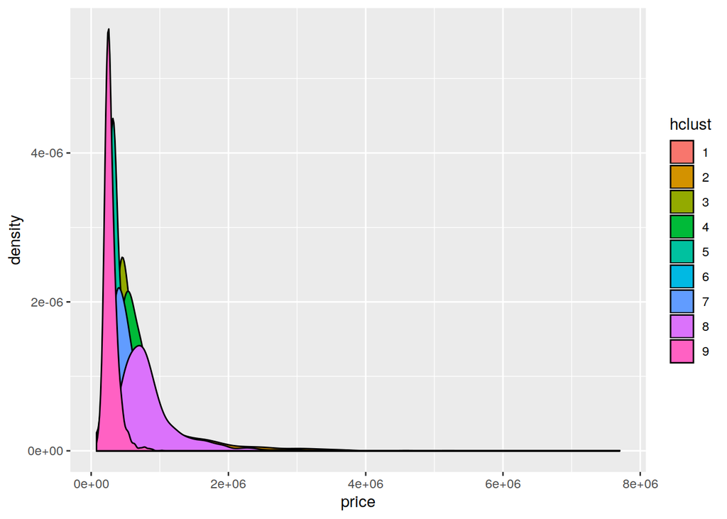

```r
df_cluster$hclust<-as.factor(df_cluster$hclust)
ggplot(data=df_cluster, aes(x=price, group=hclust ,fill=hclust)) +
    geom_density(adjust=1.5)
```

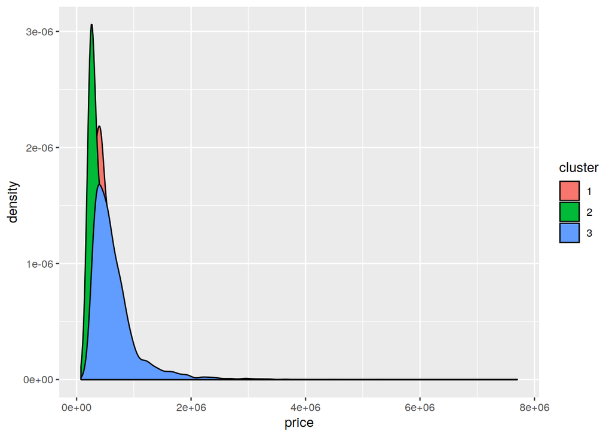

```r
df_cluster$cluster<-as.factor(df_cluster$cluster)
ggplot(data=df_cluster, aes(x=price, group=cluster ,fill=cluster)) +
    geom_density(adjust=1.5)
```

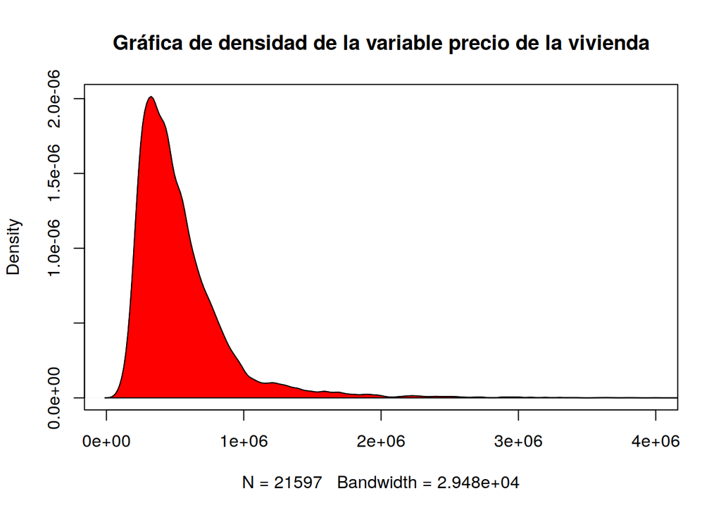

```r
densidad <- density(df_cluster$price)
plot(densidad, main="Gráfica de densidad de la variable precio de la vivienda" , xlim=c(0,4000000))
polygon(densidad, col="red")
```

```r
describe(df_cluster$price)
```

```
## df_cluster$price
##        n  missing distinct     Info     Mean      Gmd      .05      .10
##    21597        0     3622        1   540297   329526   210000   245000
##      .25      .50      .75      .90      .95
##   322000   450000   645000   887000  1160000
##
## lowest :   78000   80000   81000   82000   82500
## highest: 5350000 5570000 6890000 7060000 7700000
```

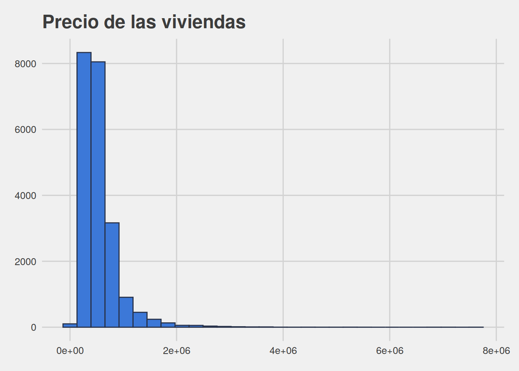

```r
histograma <- ggplot(df_cluster, aes(x=price)) +
  ggtitle("Precio de las viviendas") +
  theme_fivethirtyeight() +
  geom_histogram(color="#28324a", fill="#3c78d8")
histograma
```

Vemos que la distribución de la variable precio es muy asintótica hacia la derecha, es decir hay muchos valores extremos que puede que nos desvirtuen el análisis de la media, El punto de corte que vamos a determinar es el percentil 75 de la variable precio. La variable cluster será 1 cuando los precios sean mayores a percentil 75 de la variable precio y 0 en caso contrario

#### Contrucción de la variable Target

```r
target1 <- filter(df_cluster, price > 645000)
summary(target1)
```

```
##       X.2             X.1              X                 Y
##  Min.   :    6   Min.   :    6   Min.   :-29.306   Min.   :-28.849
##  1st Qu.: 5308   1st Qu.: 5308   1st Qu.:-12.556   1st Qu.:-16.927
##  Median :11034   Median :11034   Median : -6.444   Median : -5.068
##  Mean   :10972   Mean   :10972   Mean   : -6.725   Mean   : -3.355
##  3rd Qu.:16512   3rd Qu.:16512   3rd Qu.: -0.709   3rd Qu.:  9.205
##  Max.   :21591   Max.   :21591   Max.   : 27.464   Max.   : 29.774
##
##        id                   date          price            bedrooms
##  Min.   :1.200e+06   6/26/2014:  40   Min.   : 645500   Min.   : 1.000
##  1st Qu.:1.939e+09   6/20/2014:  39   1st Qu.: 723500   1st Qu.: 3.000
##  Median :3.886e+09   3/25/2015:  37   Median : 826000   Median : 4.000
##  Mean   :4.509e+09   4/23/2015:  37   Mean   : 987839   Mean   : 3.824
##  3rd Qu.:7.301e+09   7/14/2014:  37   3rd Qu.:1050000   3rd Qu.: 4.000
##  Max.   :9.839e+09   4/27/2015:  36   Max.   :7700000   Max.   :10.000
##                      (Other)  :5145
##    bathrooms      sqft_living       sqft_lot           floors
##  Min.   :0.750   Min.   :  890   Min.   :    520   Min.   :1.000
##  1st Qu.:2.250   1st Qu.: 2330   1st Qu.:   5400   1st Qu.:1.000
##  Median :2.500   Median : 2880   Median :   8580   Median :2.000
##  Mean   :2.675   Mean   : 2999   Mean   :  21363   Mean   :1.713
##  3rd Qu.:3.250   3rd Qu.: 3510   3rd Qu.:  14348   3rd Qu.:2.000
##  Max.   :8.000   Max.   :13540   Max.   :1651359   Max.   :3.500
##
##    waterfront           view          condition         grade
##  Min.   :0.00000   Min.   :0.0000   Min.   :1.000   Min.   : 5.000
##  1st Qu.:0.00000   1st Qu.:0.0000   1st Qu.:3.000   1st Qu.: 8.000
##  Median :0.00000   Median :0.0000   Median :3.000   Median : 9.000
##  Mean   :0.02514   Mean   :0.6258   Mean   :3.462   Mean   : 8.844
##  3rd Qu.:0.00000   3rd Qu.:0.0000   3rd Qu.:4.000   3rd Qu.:10.000
##  Max.   :1.00000   Max.   :4.0000   Max.   :5.000   Max.   :13.000
##
##    sqft_above   sqft_basement       yr_built     yr_renovated
##  Min.   : 580   Min.   :   0.0   Min.   :1900   Min.   :   0.0
##  1st Qu.:1760   1st Qu.:   0.0   1st Qu.:1951   1st Qu.:   0.0
##  Median :2430   Median :   0.0   Median :1981   Median :   0.0
##  Mean   :2534   Mean   : 464.9   Mean   :1973   Mean   : 158.2
##  3rd Qu.:3160   3rd Qu.: 890.0   3rd Qu.:2001   3rd Qu.:   0.0
##  Max.   :9410   Max.   :4820.0   Max.   :2015   Max.   :2015.0
##
##     zipcode           lat             long        sqft_living15
##  Min.   :98001   Min.   :47.16   Min.   :-122.5   Min.   : 860
##  1st Qu.:98033   1st Qu.:47.57   1st Qu.:-122.3   1st Qu.:2020
##  Median :98074   Median :47.63   Median :-122.2   Median :2570
##  Mean   :98074   Mean   :47.62   Mean   :-122.2   Mean   :2619
##  3rd Qu.:98115   3rd Qu.:47.67   3rd Qu.:-122.1   3rd Qu.:3130
##  Max.   :98199   Max.   :47.78   Max.   :-121.7   Max.   :6210
##
##    sqft_lot15     cluster      hclust     Cluster_final cluster_final
##  Min.   :   967   1:1461   8      :1550   low: 977      Length:5371
##  1st Qu.:  5250   2: 687   1      : 849   med:2319      Class :character
##  Median :  8416   3:3223   3      : 750   top:2075      Mode  :character
##  Mean   : 16300            4      : 627
##  3rd Qu.: 12912            2      : 525
##  Max.   :871200            7      : 496
##                            (Other): 574
```

```r
target0 <- filter(df_cluster, price <= 645000)
summary(target0)
```

```
##       X.2             X.1              X                 Y
##  Min.   :    1   Min.   :    1   Min.   :-30.601   Min.   :-28.717
##  1st Qu.: 5418   1st Qu.: 5418   1st Qu.: -4.623   1st Qu.:-10.053
##  Median :10720   Median :10720   Median :  2.784   Median :  1.745
##  Mean   :10742   Mean   :10742   Mean   :  2.226   Mean   :  1.110
##  3rd Qu.:16089   3rd Qu.:16089   3rd Qu.: 11.198   3rd Qu.: 11.682
##  Max.   :21597   Max.   :21597   Max.   : 27.537   Max.   : 30.132
##
##        id                   date           price           bedrooms
##  Min.   :1.000e+06   6/23/2014:  111   Min.   : 78000   Min.   : 1.000
##  1st Qu.:2.155e+09   6/25/2014:   95   1st Qu.:290000   1st Qu.: 3.000
##  Median :3.905e+09   8/26/2014:   94   Median :385000   Median : 3.000
##  Mean   :4.604e+09   7/8/2014 :   93   Mean   :392154   Mean   : 3.224
##  3rd Qu.:7.312e+09   4/14/2015:   92   3rd Qu.:491838   3rd Qu.: 4.000
##  Max.   :9.900e+09   4/22/2015:   91   Max.   :645000   Max.   :33.000
##                      (Other)  :15650
##    bathrooms      sqft_living      sqft_lot           floors
##  Min.   :0.500   Min.   : 370   Min.   :    572   Min.   :1.000
##  1st Qu.:1.500   1st Qu.:1310   1st Qu.:   5000   1st Qu.:1.000
##  Median :2.000   Median :1700   Median :   7450   Median :1.000
##  Mean   :1.931   Mean   :1776   Mean   :  13026   Mean   :1.422
##  3rd Qu.:2.500   3rd Qu.:2160   3rd Qu.:   9950   3rd Qu.:2.000
##  Max.   :7.500   Max.   :5461   Max.   :1164794   Max.   :3.500
##
##    waterfront            view          condition         grade
##  Min.   :0.000000   Min.   :0.0000   Min.   :1.000   Min.   : 3.000
##  1st Qu.:0.000000   1st Qu.:0.0000   1st Qu.:3.000   1st Qu.: 7.000
##  Median :0.000000   Median :0.0000   Median :3.000   Median : 7.000
##  Mean   :0.001726   Mean   :0.1047   Mean   :3.393   Mean   : 7.265
##  3rd Qu.:0.000000   3rd Qu.:0.0000   3rd Qu.:4.000   3rd Qu.: 8.000
##  Max.   :1.000000   Max.   :4.0000   Max.   :5.000   Max.   :11.000
##
##    sqft_above   sqft_basement       yr_built     yr_renovated
##  Min.   : 370   Min.   :   0.0   Min.   :1900   Min.   :   0.00
##  1st Qu.:1120   1st Qu.:   0.0   1st Qu.:1952   1st Qu.:   0.00
##  Median :1400   Median :   0.0   Median :1972   Median :   0.00
##  Mean   :1542   Mean   : 234.4   Mean   :1970   Mean   :  60.06
##  3rd Qu.:1850   3rd Qu.: 450.0   3rd Qu.:1994   3rd Qu.:   0.00
##  Max.   :5450   Max.   :2196.0   Max.   :2015   Max.   :2015.00
##
##     zipcode           lat             long        sqft_living15
##  Min.   :98001   Min.   :47.16   Min.   :-122.5   Min.   : 399
##  1st Qu.:98032   1st Qu.:47.42   1st Qu.:-122.3   1st Qu.:1410
##  Median :98065   Median :47.54   Median :-122.3   Median :1690
##  Mean   :98079   Mean   :47.54   Mean   :-122.2   Mean   :1777
##  3rd Qu.:98118   3rd Qu.:47.68   3rd Qu.:-122.1   3rd Qu.:2080
##  Max.   :98199   Max.   :47.78   Max.   :-121.3   Max.   :4362
##
##    sqft_lot15     cluster      hclust     Cluster_final cluster_final
##  Min.   :   651   1:5794   1      :3781   low:8993      Length:16226
##  1st Qu.:  5066   2:5000   9      :3079   med:5906      Class :character
##  Median :  7500   3:5432   5      :2133   top:1327      Mode  :character
##  Mean   : 11586            3      :2109
##  3rd Qu.:  9600            7      :1466
##  Max.   :438213            6      :1344
##                            (Other):2314
```

```r
df_cluster$cluster=as.numeric(df_cluster$hclust)


df_cluster$target[df_cluster$price> 645000] <- '1'
df_cluster$target[df_cluster$price<= 645000] <- '0'

table(df_cluster$target)
```

```
##
##     0     1
## 16226  5371
```

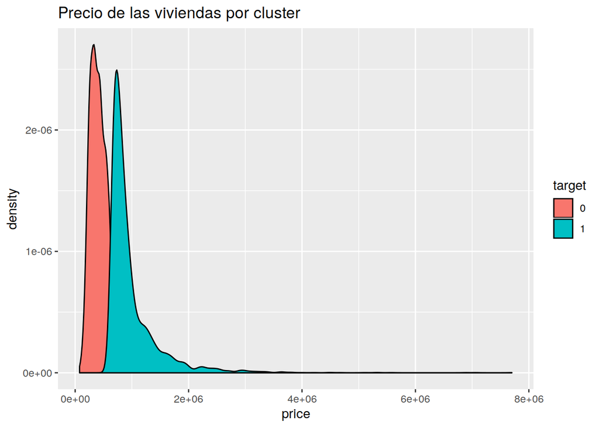

```r
df_cluster$cluster<-as.factor(df_cluster$target)
ggplot(data=df_cluster, aes(x=price, group=target ,fill=target)) +
  ggtitle("Precio de las viviendas por cluster") +
    geom_density(adjust=1.5)
```

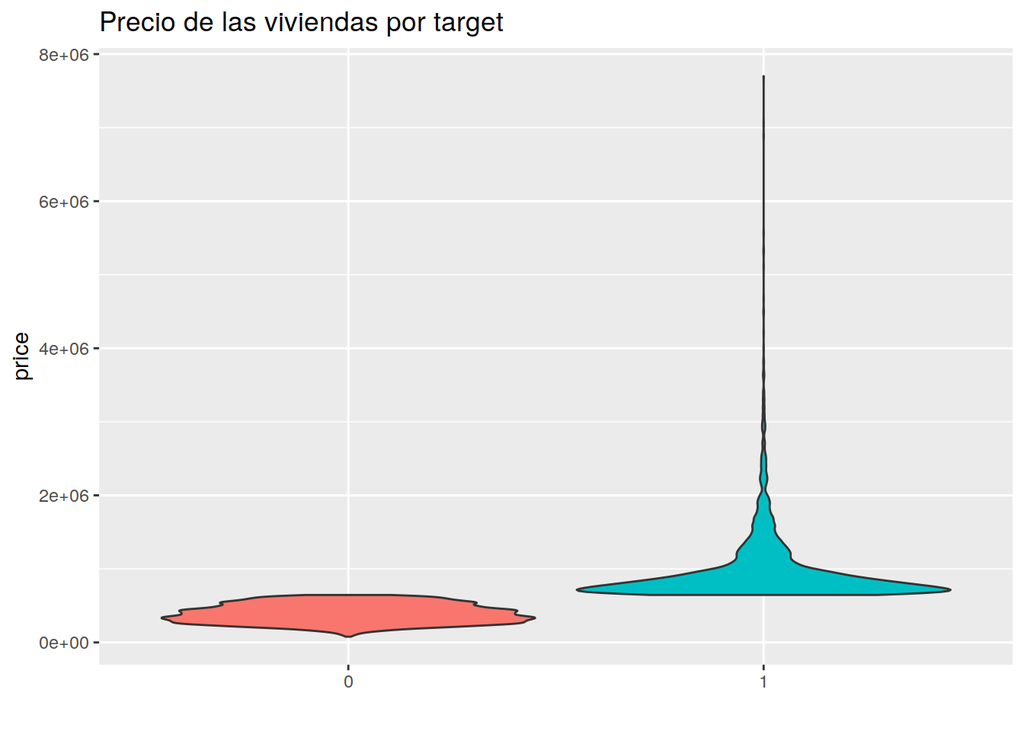

```r
 df_cluster %>%
  ggplot( aes(x=target, y=price, fill=target)) +
    ggtitle("Precio de las viviendas por target") +
    geom_violin() +
    xlab("class") +
    theme(legend.position="none") +
    xlab("")
```

# Correlaciones

En el siguiente gráfico descriptivo vemos que apraecen altas y medias correlaciones entre algunas variables por lo que vamos a tener que realizar un trabajo con las mismas con Ridge y Lasso.

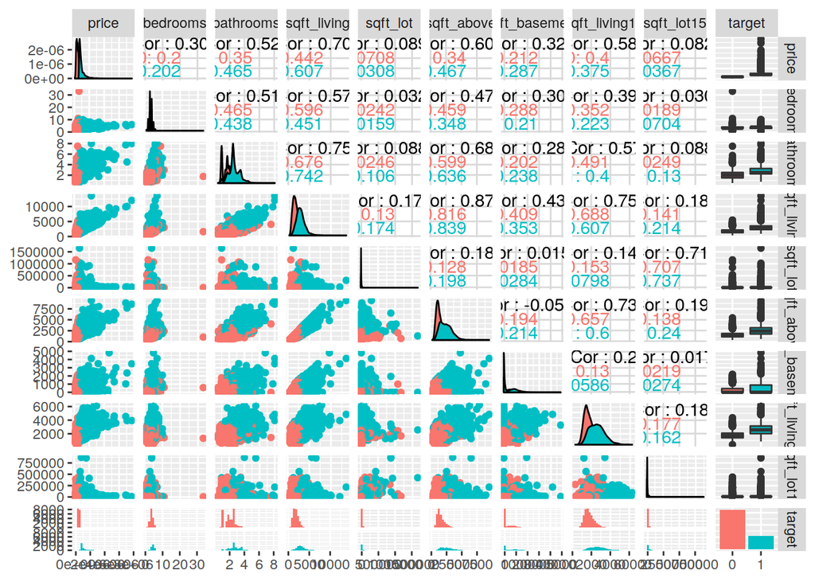

```r
pm <- ggpairs(
  df_cluster[, c( 7,8,9,10,11,17,18,24,25,30)],
  ggplot2::aes(colour=target))
pm
```

# Creación Base Train y Control

Definimos una semilla aleatoria y realizamos una partición en Train 70% , Validation 20% y Test 10%.

```r
set.seed(737)
#inTraining <- createDataPartition(df_cluster$id, p = .7, list = FALSE)
#train    <- df_cluster[inTraining,]
#control  <- df_cluster[-inTraining,]

split_data <- function(data, trn = .7, val = .2, tst = .1) {
  set.seed(737)
  spec = c(train = trn, validate = val, test = tst)
  # cutter
  g = sample(cut(seq(nrow(data)), nrow(data)*cumsum(c(0,spec)), labels = names(spec)))
  # spliter
  data <- split(data, g)
  return(data)
}

data <- split_data(df_cluster, 0.7, 0.2, 0.1)
train <- data$train
control <- data$test
validation<- data$validate


table(train$target)
```

```
##
##     0     1
## 11364  3753
```

```r
table(control$target)
```

```
##
##    0    1
## 1618  542
```

```r
table(validation$target)
```

```
##
##    0    1
## 3244 1076
```

# Ridge regression

Intenta minimizar el RSS, ridge regression incorpora un término llamado shrinkage penalty que fuerza a que los coeficientes de los predictores tiendan a cero controlada por el parámetro λ. Cuando λ=0 la penalización es nula y los resultados son equivalentes a los obtenidos por mínimos cuadrados, cuando λ=∞ todos los coeficientes son cero. La principal ventaja es la reducción de Varianza. Si todos los predictores incluidos tienen coeficientes diferentes a cero (todos contribuyen al modelo) y aproximadamente de la misma magnitud, ridge regression tiende a funcionar mejor.

Para realizar ridge regression se va a emplear la función glmnet() del paquete glmnet.

```r
#matriz con las valores de los predictores para cada observación y un vector y=target variable respuesta
x <- model.matrix(target~  (bedrooms+ bathrooms+floors+sqft_living+grade+condition+view+waterfront+                           sqft_lot+sqft_above+sqft_basement+yr_built+yr_renovated+yr_renovated+
                            sqft_living15+sqft_lot15+Cluster_final), data = train)[, -1]
head(x)
```

```
##   bedrooms bathrooms floors sqft_living grade condition view waterfront
## 1        3       1.0      1        1180     7         3    0          0
## 4        4       3.0      1        1960     7         5    0          0
## 5        3       2.0      1        1680     8         3    0          0
## 6        4       4.5      1        5420    11         3    0          0
## 8        3       1.5      1        1060     7         3    0          0
## 9        3       1.0      1        1780     7         3    0          0
##   sqft_lot sqft_above sqft_basement yr_built yr_renovated sqft_living15
## 1     5650       1180             0     1955            0          1340
## 4     5000       1050           910     1965            0          1360
## 5     8080       1680             0     1987            0          1800
## 6   101930       3890          1530     2001            0          4760
## 8     9711       1060             0     1963            0          1650
## 9     7470       1050           730     1960            0          1780
##   sqft_lot15 Cluster_finalmed Cluster_finaltop
## 1       5650                0                0
## 4       5000                0                0
## 5       7503                1                0
## 6     101930                1                0
## 8       9711                1                0
## 9       8113                1                0
```

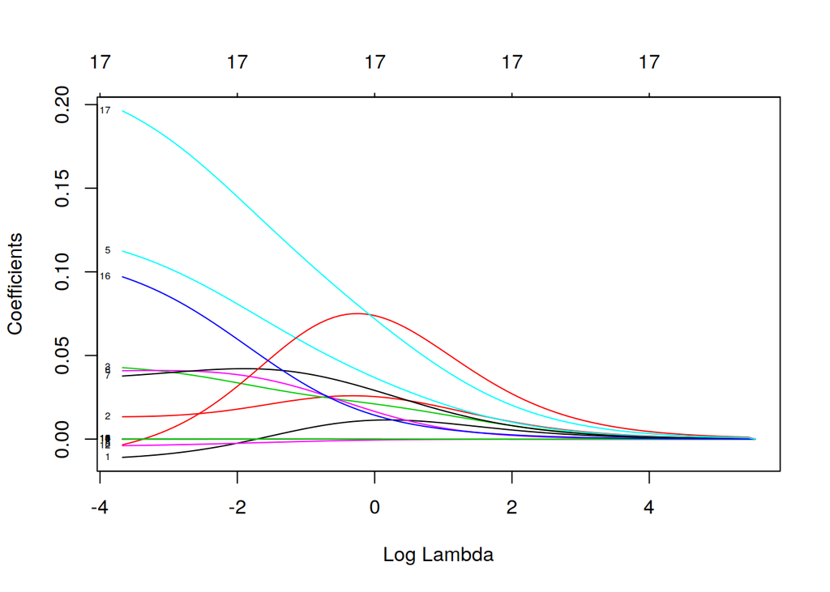

```r
y <- train$target
y <- as.integer(y)



# Para obtener un ajuste mediante ridge regression se indica argumento alpha=0.
modelos_ridge <- glmnet(x = x, y = y, alpha = 0)
plot(modelos_ridge, xvar = "lambda", label = TRUE)
```

Al aumentar el tamaño de los Lambda dismunuyen los coeficientes. Con el fin de identificar el valor de λ que da lugar al mejor modelo, se puede recurrir a Cross-Validation. La función cv.glmnet() calcula el cv-test-error, utilizando por defecto k=10.

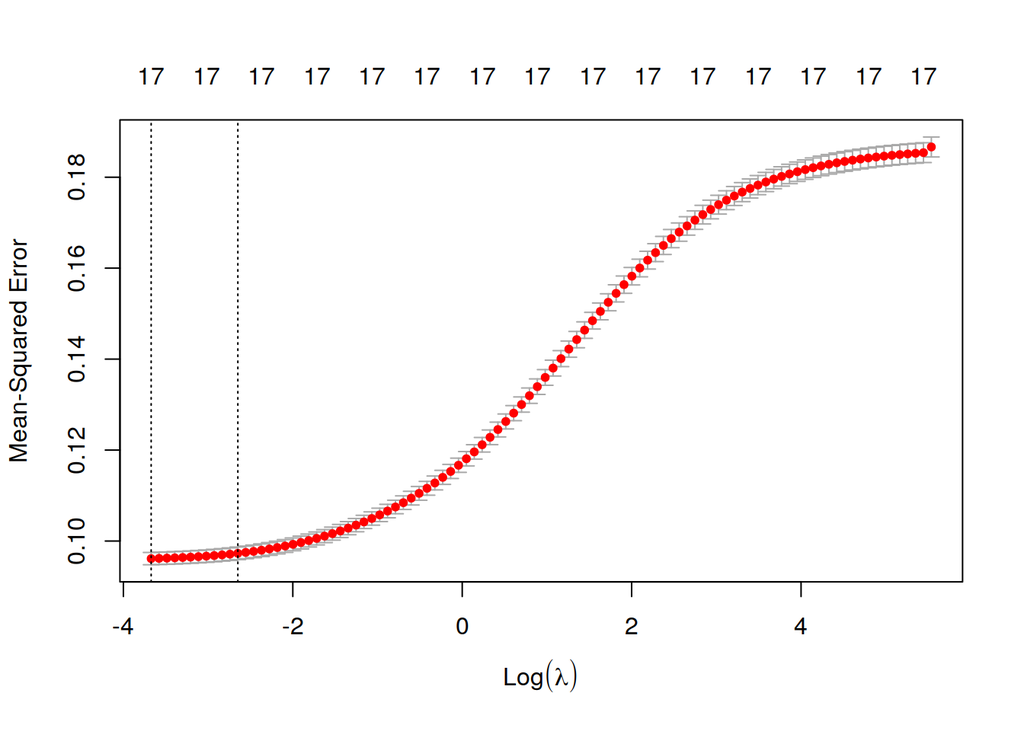

```r
set.seed(737)
cv_error_ridge <- cv.glmnet(x = x, y = y, alpha = 0, nfolds = 15,
                            type.measure = "mse")
plot(cv_error_ridge)
```

Podemos observar cómo varía el error cuadrático medio, en función del valor de regularización. Gráficamente se comprueba que el error no aumenta hasta que las variables con coeficiente mayor que cero es menor que -2, pero el menor error cuadrático medio se da para 17 variables regresoras y se mantiene constante. Es una de las grandes diferencias con Lasso.

```r
# Valor lambda con el que se consigue el mínimo test-error
cv_error_ridge$lambda.min
```

```
## [1] 0.02542122
```

```r
# Valor lambda óptimo: mayor valor de lambda con el que el test-error no se
# aleja más de 1 sd del mínimo test-error posible.
cv_error_ridge$lambda.1se
```

```
## [1] 0.07073607
```

```r
# Se muestra el valor de los coeficientes para el valor de lambda óptimo

modelo_final_ridge <- glmnet(x = x, y = y, alpha = 0, lambda = cv_error_ridge$lambda.1se)
coef(modelo_final_ridge)
```

```
## 18 x 1 sparse Matrix of class "dgCMatrix"
##                             s0
## (Intercept)       6.103194e+00
## bedrooms         -6.975913e-03
## bathrooms         1.508731e-02
## floors            3.821222e-02
## sqft_living       5.687788e-05
## grade             9.519157e-02
## condition         4.068419e-02
## view              4.076669e-02
## waterfront        1.292870e-02
## sqft_lot          4.959385e-08
## sqft_above        5.792261e-05
## sqft_basement     4.164063e-05
## yr_built         -3.164416e-03
## yr_renovated     -1.651793e-05
## sqft_living15     7.787366e-05
## sqft_lot15       -3.856229e-07
## Cluster_finalmed  7.737745e-02
## Cluster_finaltop  1.686181e-01
```

# Lasso

El método lasso, al igual que ridge regression, fuerza a que las estimaciones de los coeficientes de los predictores tiendan a cero. La diferencia es que lasso sí es capaz de fijar algunos de ellos exactamente a cero, lo que permite además de reducir la varianza, realizar selección de predictores. ∑i=1n(yi−β0−∑j=1pβjxij)2+λ∑j=1p|βj|=RSS+λ∑j=1p|βj|

Cuando solo un pequeño número de predictores de entre todos los incluidos tienen coeficientes sustanciales y el resto tienen valores muy pequeños o iguales a cero, lasso genera mejores modelos.

Selección del tunning parameter λ

```
Determinar el grado de penalización, seleccionamos un rango de valores de λ y se estima el cross-validation error resultante para cada uno, finalmente se selecciona el valor de λ para el que el error es menor y se ajusta de nuevo el modelo, esta vez empleando todas las observaciones.
```

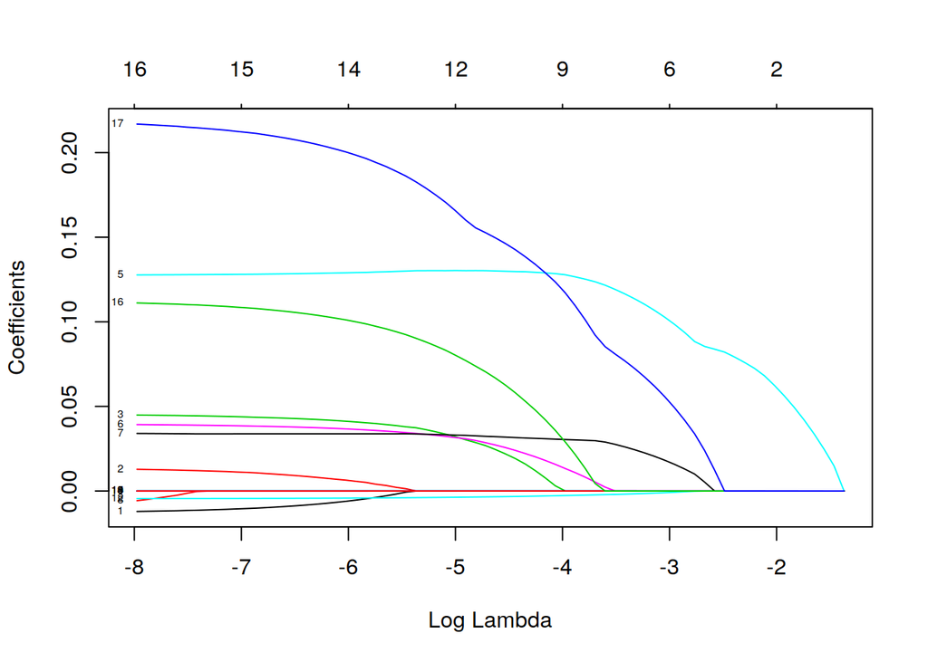

```r
modelos_lasso <- glmnet(x = x, y = y, alpha = 1)
plot(modelos_lasso, xvar = "lambda", label = TRUE)
```

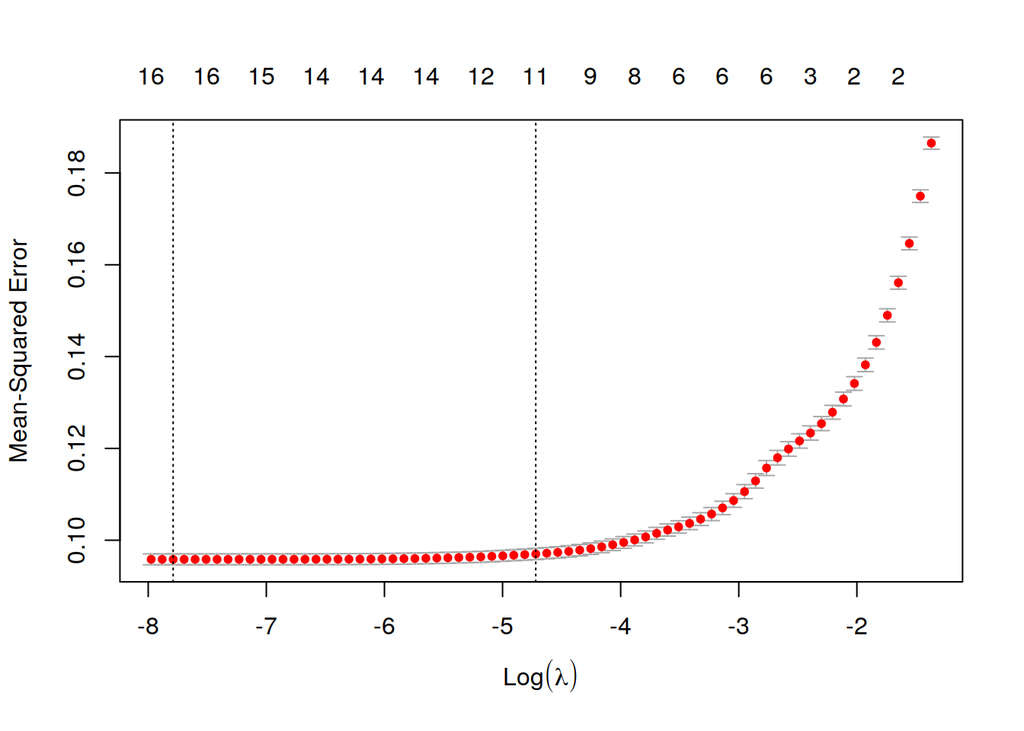

```r
set.seed(737)
cv_error_lasso <- cv.glmnet(x = x, y = y, alpha = 1, nfolds = 10)
plot(cv_error_lasso)
```

```r
cv_error_lasso$lambda.min
```

```
## [1] 0.0004143026
```

```r
cv_error_lasso$lambda.1se
```

```
## [1] 0.008925879
```

```r
# Se reajusta el modelo con todas las observaciones empleando el valor de
# lambda óptimo

modelo_final_lasso <- glmnet(x = x, y = y, alpha = 1, lambda = cv_error_lasso$lambda.1se)
coef(modelo_final_lasso)
```

```
## 18 x 1 sparse Matrix of class "dgCMatrix"
##                             s0
## (Intercept)       6.595800e+00
## bedrooms          .
## bathrooms         .
## floors            2.666460e-02
## sqft_living       9.143041e-05
## grade             1.300344e-01
## condition         2.862539e-02
## view              3.238449e-02
## waterfront        .
## sqft_lot          .
## sqft_above        6.118704e-06
## sqft_basement     .
## yr_built         -3.487305e-03
## yr_renovated      .
## sqft_living15     6.692732e-05
## sqft_lot15       -6.026306e-09
## Cluster_finalmed  7.061614e-02
## Cluster_finaltop  1.527260e-01
```

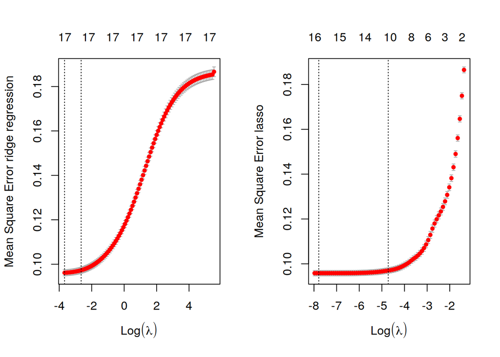

```r
par(mfrow = c(1,2))
plot(cv_error_ridge,ylab = "Mean Square Error ridge regression" )
abline(h = 120000)
plot(cv_error_lasso,ylab = "Mean Square Error lasso")
abline(h = 120000)
```

```r
par(mfrow = c(1,1))
```

# GLM Link Logit y Probit

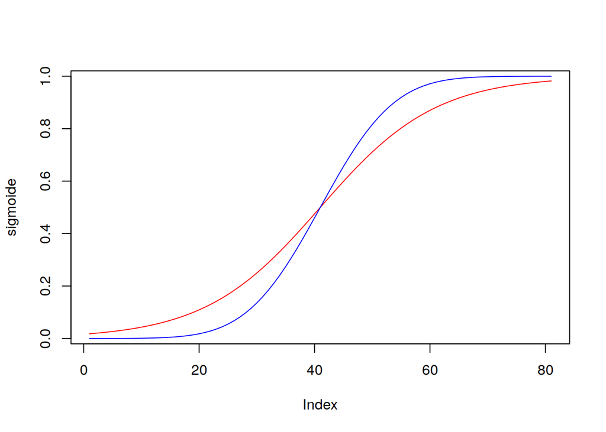

```r
# Diferencia entre el logit y el probit
X=seq(from=-4,to=4,by=0.1)
sigmoide=1/(1+exp(-X))
cumulative<-pnorm(X, 0, 1)
plot(sigmoide,type="l",col="red")
lines(cumulative,col="blue")
```

## Regresión Logistica (Logit)

A partir de las variables del Lasso

```r
train_glm1 = glm(target ~ floors + grade + condition + view + sqft_above + yr_built + sqft_living15 + Cluster_final ,
               family = binomial,
               data = train )
summary(train_glm1)
```

```
##
## Call:
## glm(formula = target ~ floors + grade + condition + view + sqft_above +
##     yr_built + sqft_living15 + Cluster_final, family = binomial,
##     data = train)
##
## Deviance Residuals:
##     Min       1Q   Median       3Q      Max
## -3.3215  -0.4129  -0.2028  -0.0266   3.4445
##
## Coefficients:
##                    Estimate Std. Error z value Pr(>|z|)
## (Intercept)       7.017e+01  2.628e+00  26.702  < 2e-16 ***
## floors            4.191e-01  7.004e-02   5.984 2.17e-09 ***
## grade             1.450e+00  4.678e-02  30.993  < 2e-16 ***
## condition         5.717e-01  4.777e-02  11.967  < 2e-16 ***
## view              2.564e-01  3.473e-02   7.383 1.54e-13 ***
## sqft_above        8.171e-04  6.321e-05  12.927  < 2e-16 ***
## yr_built         -4.541e-02  1.411e-03 -32.176  < 2e-16 ***
## sqft_living15     6.844e-04  6.490e-05  10.546  < 2e-16 ***
## Cluster_finalmed  1.511e+00  7.487e-02  20.183  < 2e-16 ***
## Cluster_finaltop  1.542e+00  8.458e-02  18.231  < 2e-16 ***
## ---
## Signif. codes:  0 '***' 0.001 '**' 0.01 '*' 0.05 '.' 0.1 ' ' 1
##
## (Dispersion parameter for binomial family taken to be 1)
##
##     Null deviance: 16943.7  on 15116  degrees of freedom
## Residual deviance:  8370.4  on 15107  degrees of freedom
## AIC: 8390.4
##
## Number of Fisher Scoring iterations: 6
```

Viendo los resultados de la regresión logística podemos afirmar que todas las variables introducidas en el modelo son significativas a nivel estadístico, aunque podemos apreciar en las variables Floors y View un valor del estadísitico no demasiado alto lo cual nos dice que no son especialmete explicativas.

### Vamos a probar un modelo Nuevo Versión 2 excluyendo estas variables

```r
train_glm2 = update(train_glm1, . ~ . - view - floors) # Eliminamos dos predictores
anova(train_glm1, train_glm2, test = "Chisq")
```

```
## Analysis of Deviance Table
##
## Model 1: target ~ floors + grade + condition + view + sqft_above + yr_built +
##     sqft_living15 + Cluster_final
## Model 2: target ~ grade + condition + sqft_above + yr_built + sqft_living15 +
##     Cluster_final
##   Resid. Df Resid. Dev Df Deviance  Pr(>Chi)
## 1     15107     8370.4
## 2     15109     8461.5 -2  -91.097 < 2.2e-16 ***
## ---
## Signif. codes:  0 '***' 0.001 '**' 0.01 '*' 0.05 '.' 0.1 ' ' 1
```

Esta salida nos dice que el ajuste es estadísticamente significativo pero a nivel negocio son importantes y en el primer modelo eran significativas por lo que las vamos a mantener.

```r
head(predict(train_glm1, type = "response")) # Probabilidades en escala de la salida
```

```
##          1          4          5          6          8          9
## 0.01171684 0.02107990 0.09943194 0.99523562 0.04019918 0.04946034
```

```r
summary(train_glm1$fitted.values)
```

```
##      Min.   1st Qu.    Median      Mean   3rd Qu.      Max.
## 0.0000455 0.0199307 0.0755619 0.2482635 0.3757317 0.9999988
```

### Matriz de Confusión

#### ROC Plot

Vemos en la Matriz de Confusión que el modelo tenemos problemas con Falsos Positivos, el modelo predice de forma notable una casa como de Precio bajo cuando son de precio Alto. Esto para nuestro negocio tiene implicaciones ya que lo que queremos evitar es no pronosticar bien las casas de Precio Alto.

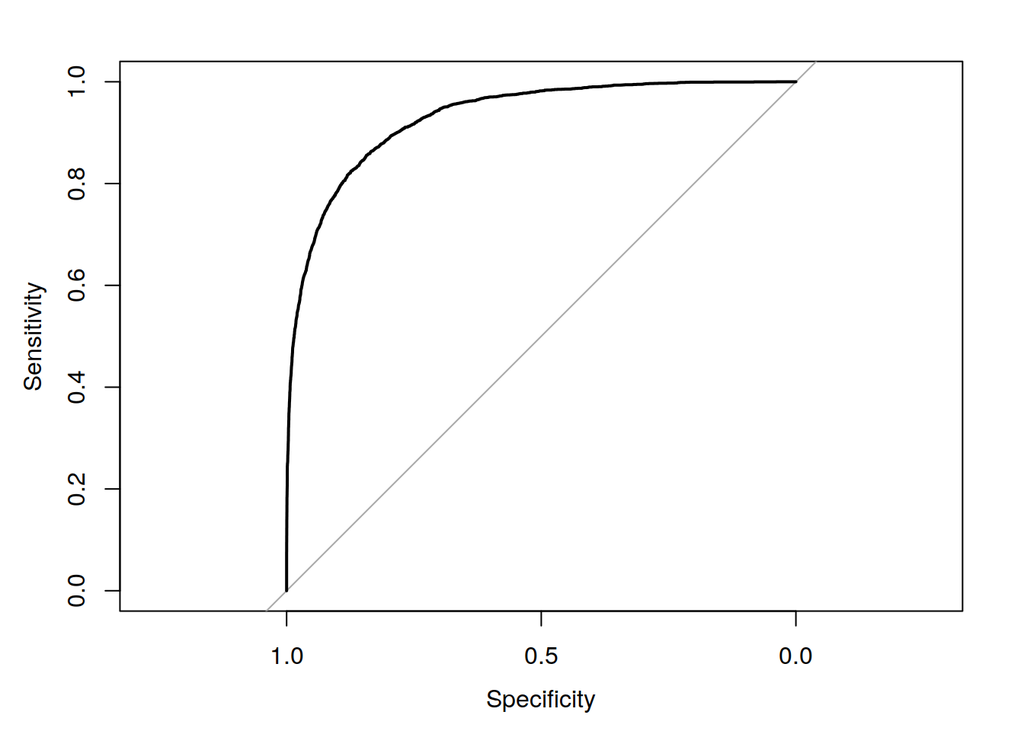

```r
predictions <- predict(train_glm1, train,type='response')
plot.roc(train$target, predictions)
```

```r
table(pred = predictions > 0.5, obs = train$target)
```

```
##        obs
## pred        0     1
##   FALSE 10758  1187
##   TRUE    606  2566
```

```r
data = as.numeric(predictions>0.5)
data=as.factor(data)
y_test=as.factor(train$target)

# use caret and compute a confusion matrix
confusionMatrix(data, y_test)
```

```
## Confusion Matrix and Statistics
##
##           Reference
## Prediction     0     1
##          0 10758  1187
##          1   606  2566
##
##                Accuracy : 0.8814
##                  95% CI : (0.8761, 0.8865)
##     No Information Rate : 0.7517
##     P-Value [Acc > NIR] : < 2.2e-16
##
##                   Kappa : 0.6649
##
##  Mcnemar's Test P-Value : < 2.2e-16
##
##             Sensitivity : 0.9467
##             Specificity : 0.6837
##          Pos Pred Value : 0.9006
##          Neg Pred Value : 0.8090
##              Prevalence : 0.7517
##          Detection Rate : 0.7116
##    Detection Prevalence : 0.7902
##       Balanced Accuracy : 0.8152
##
##        'Positive' Class : 0
##
```

```r
#VEro testing ROCit library
library(ROCit)
```

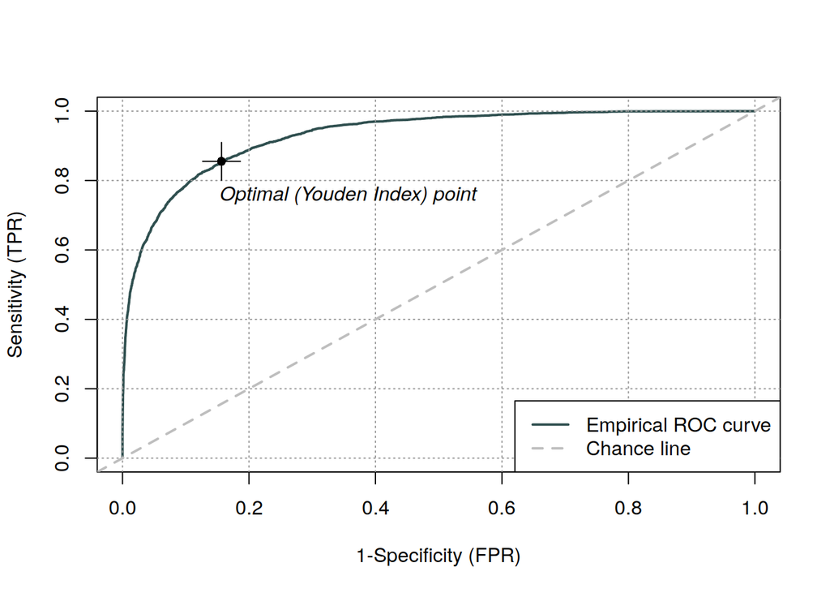

```r
ROCit_obj <- rocit(score = predictions, class = train$target)
plot(ROCit_obj)
```

```r
#END Vero testing
```

Tal y como se puede observar, sobre la curva ROC tenemos que tiende mas hacia los 90º que hacia los 45º. Esto lo que nos indica es que pese a tener falsos positivos el test ha salido bastante preciso.

#### Gain chart

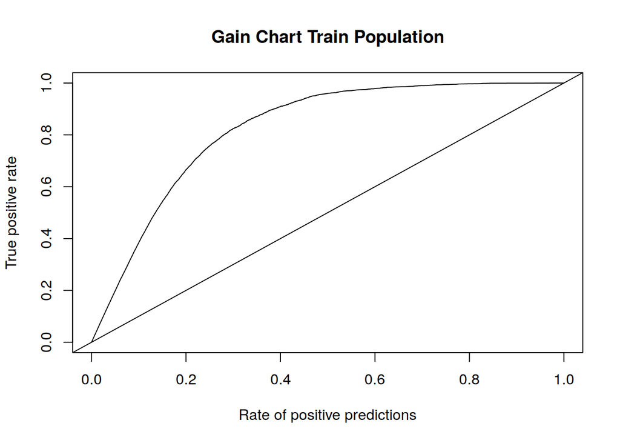

```r
require(ROCR)

predictions <- predict(train_glm1, train,type='response')
pred<- prediction(predictions,  train$target)
gain <- performance(pred, "tpr", "rpp")
plot(gain, main = "Gain Chart Train Population")
abline(a=0,b=1)
```

Por la grafica obtenida se observa que al 70% aprox ya se tiene una respuesta del 98%. Esto permitira ahorrar unos costes de aproximadamente un 30% donde solo perderiamos el 2% de las respuestas.

#### Lift chart

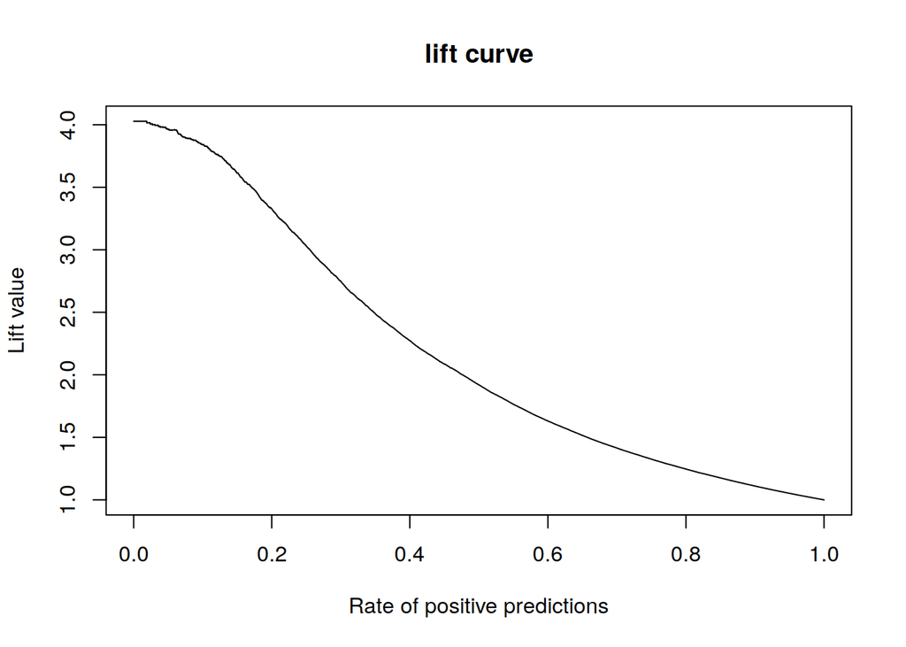

```r
# lift chart
perf <- performance(pred,"lift","rpp")
plot(perf, main="lift curve")
```

### Obteniendo un threshold mas preciso para Logit

[figure not shown]

```r
cutoffs <- seq(0.1,0.9,0.1)
accuracy <- NULL
for (i in seq(along = cutoffs)){
    prediction <- ifelse(train_glm1$fitted.values >= cutoffs[i], 1, 0) #Predicting for cut-off
accuracy <- c(accuracy,length(which(train$y ==prediction))/length(prediction)*100)
}

plot(cutoffs, accuracy, pch =19,type='b',col= "steelblue",
     main ="Logistic Regression", xlab="Cutoff Level", ylab = "Accuracy %")
```

### Función del Calculo del Error para optimizar el resultado de logit

Vamos a calcular la precisión general o tasa de error para un Cutoff de 0.5 obtenemos un 11,86% de tasa de error

```r
## a function for error rate
get_Error_Rate = function(trues, predicted_prb, cutoff){
  preds=ifelse(predicted_prb<cutoff,0,1)
  tab=table(preds, trues)
  round((tab[1,2]+tab[2,1])/sum(tab), 4)
}
get_Error_Rate(train$target,train_glm1$fitted.values, 0.1)
```

```
## [1] 0.235
```

```r
get_Error_Rate(train$target,train_glm1$fitted.values, 0.2)
```

```
## [1] 0.1643
```

```r
get_Error_Rate(train$target,train_glm1$fitted.values, 0.3)
```

```
## [1] 0.132
```

```r
get_Error_Rate(train$target,train_glm1$fitted.values, 0.4)
```

```
## [1] 0.1201
```

```r
get_Error_Rate(train$target,train_glm1$fitted.values, 0.5)
```

```
## [1] 0.1186
```

```r
get_Error_Rate(train$target,train_glm1$fitted.values, 0.6)
```

```
## [1] 0.1207
```

```r
get_Error_Rate(train$target,train_glm1$fitted.values, 0.7)
```

```
## [1] 0.1279
```

```r
get_Error_Rate(train$target,train_glm1$fitted.values, 0.8)
```

```
## [1] 0.1438
```

```r
get_Error_Rate(train$target,train_glm1$fitted.values, 0.9)
```

```
## [1] 0.1651
```

```r
#plot(get_Error_Rate(train$target,model_logit1$fitted.values, 0.1:1.0))
```

### Validacion del modelo Logit con el dataset de Validation

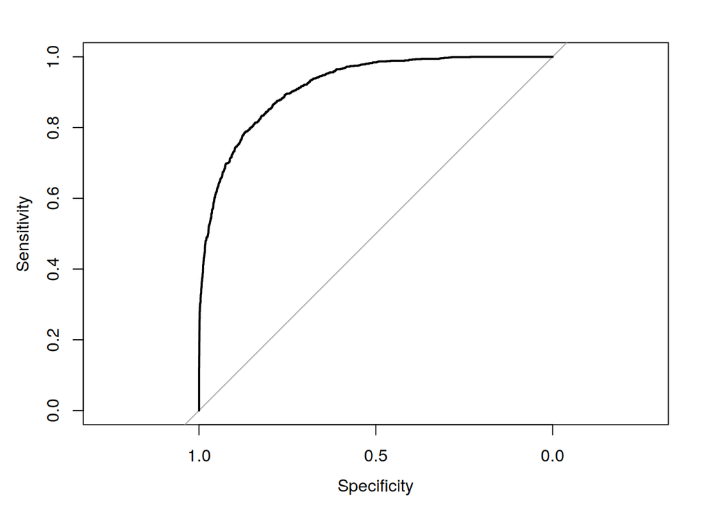

```r
predictionsLogit <- predict(train_glm1, validation,type='response')
plot.roc(validation$target, predictionsLogit)
```

```r
table(pred = predictionsLogit > 0.5, obs = validation$target)
```

```
##        obs
## pred       0    1
##   FALSE 3035  366
##   TRUE   209  710
```

```r
data = as.numeric(predictionsLogit>0.5)
data=as.factor(data)
y_test=as.factor(validation$target)
    # use caret and compute a confusion matrix
confusionMatrix(data, y_test)
```

```
## Confusion Matrix and Statistics
##
##           Reference
## Prediction    0    1
##          0 3035  366
##          1  209  710
##
##                Accuracy : 0.8669
##                  95% CI : (0.8564, 0.8769)
##     No Information Rate : 0.7509
##     P-Value [Acc > NIR] : < 2.2e-16
##
##                   Kappa : 0.6259
##
##  Mcnemar's Test P-Value : 7.736e-11
##
##             Sensitivity : 0.9356
##             Specificity : 0.6599
##          Pos Pred Value : 0.8924
##          Neg Pred Value : 0.7726
##              Prevalence : 0.7509
##          Detection Rate : 0.7025
##    Detection Prevalence : 0.7873
##       Balanced Accuracy : 0.7977
##
##        'Positive' Class : 0
##
```

## Train Model Binomail Link Probit

```r
train$yr_built=as.numeric(train$yr_built)

model_probit1 = glm(target ~ floors + grade + condition + view + sqft_above + yr_built + sqft_living15 + Cluster_final ,
               family = binomial (link="probit") ,
               data = train )
summary(model_probit1)
```

```
##
## Call:
## glm(formula = target ~ floors + grade + condition + view + sqft_above +
##     yr_built + sqft_living15 + Cluster_final, family = binomial(link = "probit"),
##     data = train)
##
## Deviance Residuals:
##     Min       1Q   Median       3Q      Max
## -3.6703  -0.4286  -0.1774  -0.0035   3.8798
##
## Coefficients:
##                    Estimate Std. Error z value Pr(>|z|)
## (Intercept)       3.889e+01  1.420e+00  27.396  < 2e-16 ***
## floors            2.177e-01  3.788e-02   5.747 9.10e-09 ***
## grade             7.977e-01  2.510e-02  31.781  < 2e-16 ***
## condition         3.029e-01  2.619e-02  11.566  < 2e-16 ***
## view              1.508e-01  1.964e-02   7.676 1.64e-14 ***
## sqft_above        4.483e-04  3.477e-05  12.894  < 2e-16 ***
## yr_built         -2.512e-02  7.551e-04 -33.269  < 2e-16 ***
## sqft_living15     3.942e-04  3.601e-05  10.947  < 2e-16 ***
## Cluster_finalmed  8.194e-01  4.000e-02  20.483  < 2e-16 ***
## Cluster_finaltop  8.614e-01  4.680e-02  18.404  < 2e-16 ***
## ---
## Signif. codes:  0 '***' 0.001 '**' 0.01 '*' 0.05 '.' 0.1 ' ' 1
##
## (Dispersion parameter for binomial family taken to be 1)
##
##     Null deviance: 16943.7  on 15116  degrees of freedom
## Residual deviance:  8362.9  on 15107  degrees of freedom
## AIC: 8382.9
##
## Number of Fisher Scoring iterations: 6
```

```r
head(predict(model_probit1, type = "response")) # Probabilidades en escala de la salida
```

```
##           1           4           5           6           8           9
## 0.007035223 0.015726870 0.108073433 0.998472061 0.038476190 0.049828478
```

```r
summary(model_probit1$fitted.values)
```

```
##    Min. 1st Qu.  Median    Mean 3rd Qu.    Max.
## 0.00000 0.01523 0.08042 0.24778 0.38288 1.00000
```

### Matriz de Confusion Probit

Igual que para logit vamos a comprobar cuantos falsos positivos obtenemos y como se podrian evitar

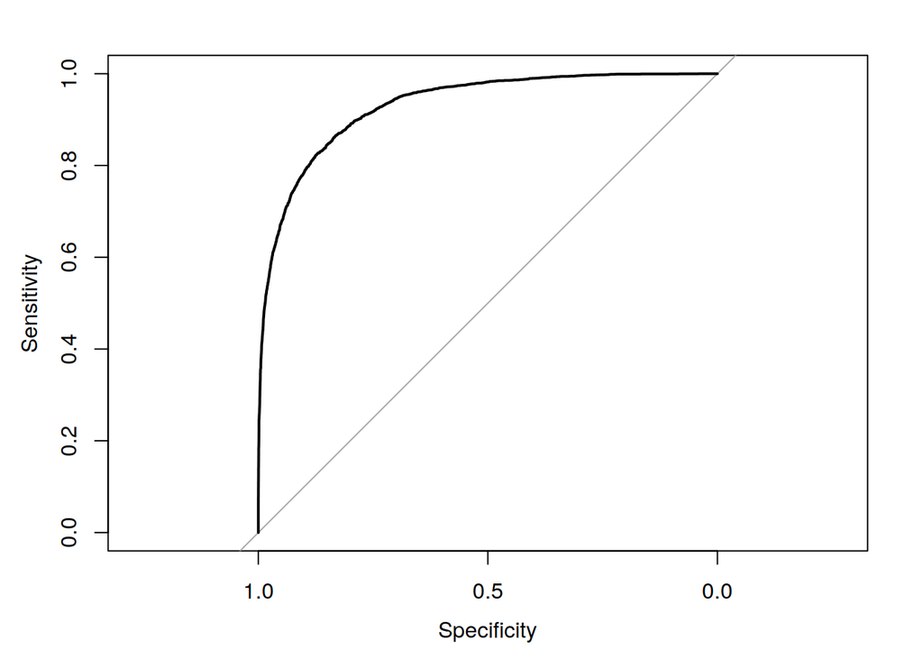

```r
predictions <- predict(model_probit1, train,type='response')
plot.roc(train$target, predictions)
```

```r
table(pred = predictions > 0.5, obs = train$target)
```

```
##        obs
## pred        0     1
##   FALSE 10773  1198
##   TRUE    591  2555
```

```r
data = as.numeric(predictions>0.5)
data=as.factor(data)
y_test=as.factor(train$target)

# use caret and compute a confusion matrix
confusionMatrix(data, y_test)
```

```
## Confusion Matrix and Statistics
##
##           Reference
## Prediction     0     1
##          0 10773  1198
##          1   591  2555
##
##                Accuracy : 0.8817
##                  95% CI : (0.8764, 0.8868)
##     No Information Rate : 0.7517
##     P-Value [Acc > NIR] : < 2.2e-16
##
##                   Kappa : 0.6648
##
##  Mcnemar's Test P-Value : < 2.2e-16
##
##             Sensitivity : 0.9480
##             Specificity : 0.6808
##          Pos Pred Value : 0.8999
##          Neg Pred Value : 0.8121
##              Prevalence : 0.7517
##          Detection Rate : 0.7126
##    Detection Prevalence : 0.7919
##       Balanced Accuracy : 0.8144
##
##        'Positive' Class : 0
##
```

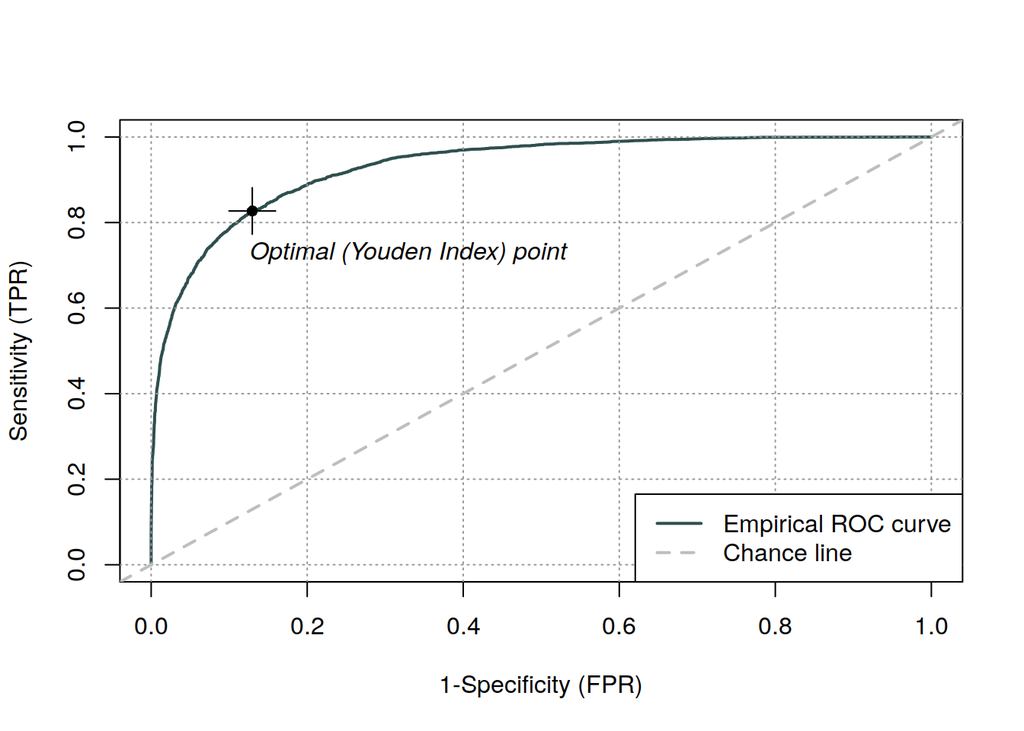

```r
#VEro testing ROCit library
library(ROCit)
ROCit_obj <- rocit(score = predictions, class = train$target)
plot(ROCit_obj)
```

```r
#END Vero testing
```

#### Gain chart

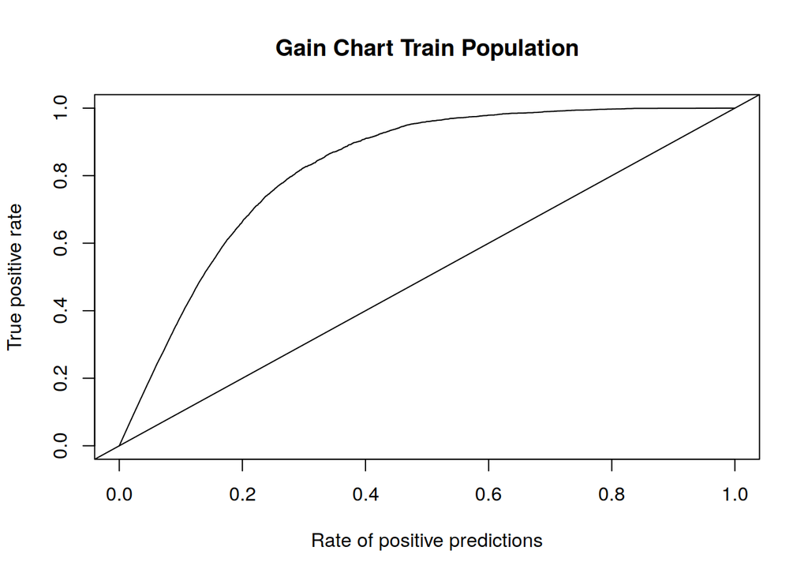

```r
require(ROCR)

predictions <- predict(model_probit1, train,type='response')
pred<- prediction(predictions,  train$target)
gain <- performance(pred, "tpr", "rpp")
plot(gain, main = "Gain Chart Train Population")
abline(a=0,b=1)
```

#### Lift chart

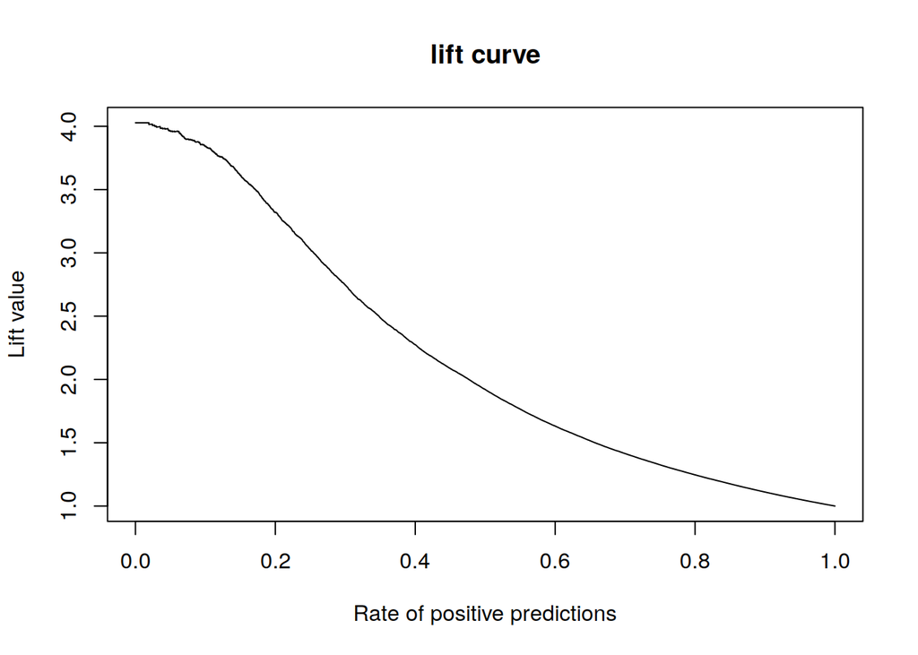

```r
# lift chart
perf <- performance(pred,"lift","rpp")
plot(perf, main="lift curve")
```

### Obteniendo un threshold mas preciso para Progit

[figure not shown]

```r
cutoffs <- seq(0.1,0.9,0.1)
accuracy <- NULL
for (i in seq(along = cutoffs)){
    prediction <- ifelse(model_probit1$fitted.values >= cutoffs[i], 1, 0) #Predicting for cut-off
accuracy <- c(accuracy,length(which(train$y ==prediction))/length(prediction)*100)
}

plot(cutoffs, accuracy, pch =19,type='b',col= "steelblue",
     main ="Logistic Regression", xlab="Cutoff Level", ylab = "Accuracy %")
```

### Función del Calculo del Error para optimizar el resultado de Probit

Vamos a calcular la precisión general o tasa de error para un Cutoff de 0.5 obtenemos un 11,83% de tasa de error

```r
## a function for error rate
get_Error_Rate = function(trues, predicted_prb, cutoff){
  preds=ifelse(predicted_prb<cutoff,0,1)
  tab=table(preds, trues)
  round((tab[1,2]+tab[2,1])/sum(tab), 4)
}
get_Error_Rate(train$target,model_probit1$fitted.values, 0.1)
```

```
## [1] 0.2436
```

```r
get_Error_Rate(train$target,model_probit1$fitted.values, 0.2)
```

```
## [1] 0.1727
```

```r
get_Error_Rate(train$target,model_probit1$fitted.values, 0.3)
```

```
## [1] 0.1354
```

```r
get_Error_Rate(train$target,model_probit1$fitted.values, 0.4)
```

```
## [1] 0.1212
```

```r
get_Error_Rate(train$target,model_probit1$fitted.values, 0.5)
```

```
## [1] 0.1183
```

```r
get_Error_Rate(train$target,model_probit1$fitted.values, 0.6)
```

```
## [1] 0.1207
```

```r
get_Error_Rate(train$target,model_probit1$fitted.values, 0.7)
```

```
## [1] 0.131
```

```r
get_Error_Rate(train$target,model_probit1$fitted.values, 0.8)
```

```
## [1] 0.1478
```

```r
get_Error_Rate(train$target,model_probit1$fitted.values, 0.9)
```

```
## [1] 0.169
```

```r
#plot(get_Error_Rate(train$target,model_logit1$fitted.values, 0.1:1.0))
```

### Validacion del modelo Probit con el dataset de Validation

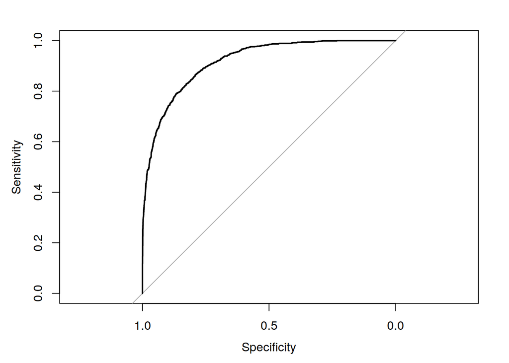

```r
predictionsProbit <- predict(model_probit1, validation,type='response')
plot.roc(validation$target, predictionsProbit)
```

```r
table(pred = predictionsProbit > 0.5, obs = validation$target)
```

```
##        obs
## pred       0    1
##   FALSE 3041  372
##   TRUE   203  704
```

```r
data = as.numeric(predictionsProbit>0.5)
data=as.factor(data)
y_test=as.factor(validation$target)
    # use caret and compute a confusion matrix
confusionMatrix(data, y_test)
```

```
## Confusion Matrix and Statistics
##
##           Reference
## Prediction    0    1
##          0 3041  372
##          1  203  704
##
##                Accuracy : 0.8669
##                  95% CI : (0.8564, 0.8769)
##     No Information Rate : 0.7509
##     P-Value [Acc > NIR] : < 2.2e-16
##
##                   Kappa : 0.6245
##
##  Mcnemar's Test P-Value : 2.451e-12
##
##             Sensitivity : 0.9374
##             Specificity : 0.6543
##          Pos Pred Value : 0.8910
##          Neg Pred Value : 0.7762
##              Prevalence : 0.7509
##          Detection Rate : 0.7039
##    Detection Prevalence : 0.7900
##       Balanced Accuracy : 0.7958
##
##        'Positive' Class : 0
##
```